# Tidy Text Analysis

# Overview

- Operationalize project research questions into data tasks
- Text processing and Sentiment analysis

# Goals

- Operationalize what data/format each group needs for their project question
- Understand the minimum necessary information about text processing and sentiment analysis.
- Identify what parts of text analysis will be needed for your groups project
- Replicate the steps needed for text processing and sentiment scoring to your twitter project data (even if it’s not part of your research question).

# Learning resources

This work follows from the [Text mining with R](https://www.tidytextmining.com/) book. These notes serve as a demonstration of how these topics apply to our twitter data.

- Tidytext book and vignette (recommended)
  - [Vignette](https://cran.r-project.org/web/packages/tidytext/vignettes/tidytext.html)
  - [Text mining with R book](https://www.tidytextmining.com/)
- [Sentiment Analysis](https://cran.r-project.org/web/packages/SentimentAnalysis/vignettes/SentimentAnalysis.html) package vignette.

```r
library(tidyverse)
library(tidytext)
```

## Data Cleaning

Read in data. Extract tweet text into a new tibble.

```r
cf <- readRDS("C:/Users/Robin/Google Drive/Teaching/POLS 624 S20/Twitter project docs/data/campfire-tweets-2020-04-27.Rds")
tweet <- tibble(status_id=cf$status_id, text=cf$text)
tweet$text[1]
```

```
## [1] "Is #fire a solid, a liquid, or a gas? - Elizabeth Cox https://t.co/yxZtJ0R0cv"
```

Tokenization using the `unnest_tokens()` function.

```r
tweet %>% unnest_tokens(word, text) %>% print(n=15)
```

```
## # A tibble: 1,797,459 x 2
##    status_id           word
##    <chr>               <chr>
##  1 1060184727515226112 is
##  2 1060184727515226112 fire
##  3 1060184727515226112 a
##  4 1060184727515226112 solid
##  5 1060184727515226112 a
##  6 1060184727515226112 liquid
##  7 1060184727515226112 or
##  8 1060184727515226112 a
##  9 1060184727515226112 gas
## 10 1060184727515226112 elizabeth
## 11 1060184727515226112 cox
## 12 1060184727515226112 https
## 13 1060184727515226112 t.co
## 14 1060184727515226112 yxztj0r0cv
## 15 1060184491803561984 northern
## # ... with 1,797,444 more rows
```

Notice when we unnested the tokens, it removed the `#` and `@` symbols. We can use a custom token function for tweets. We should also remove symbols such as `&`, `>` and `<`.

```r
remove_reg <- "&amp;|&lt;|&gt;"
tweet_words <- tweet %>%
                  mutate(text = str_remove_all(text, remove_reg)) %>%
                  unnest_tokens(word, text, token="tweets")
```

```
## Using `to_lower = TRUE` with `token = 'tweets'` may not preserve URLs.
```

```r
tweet_words %>% print(n=15)
```

```
## # A tibble: 1,679,814 x 2
##    status_id           word
##    <chr>               <chr>
##  1 1060184727515226112 is
##  2 1060184727515226112 #fire
##  3 1060184727515226112 a
##  4 1060184727515226112 solid
##  5 1060184727515226112 a
##  6 1060184727515226112 liquid
##  7 1060184727515226112 or
##  8 1060184727515226112 a
##  9 1060184727515226112 gas
## 10 1060184727515226112 elizabeth
## 11 1060184727515226112 cox
## 12 1060184727515226112 https://t.co/yxztj0r0cv
## 13 1060184491803561984 northern
## 14 1060184491803561984 california
## 15 1060184491803561984 back
## # ... with 1,679,799 more rows
```

Remove stop words - what’s in the stop words lexicon anyhow?

```r
data("stop_words")
head(stop_words)
```

```
## # A tibble: 6 x 2
##   word      lexicon
##   <chr>     <chr>
## 1 a         SMART
## 2 a's       SMART
## 3 able      SMART
## 4 about     SMART
## 5 above     SMART
## 6 according SMART
```

```r
table(stop_words$lexicon)
```

```
##
##     onix    SMART snowball
##      404      571      174
```

```r
tweet_words_nostop <- tweet_words %>% anti_join(stop_words)
head(tweet_words_nostop)
```

```
## # A tibble: 6 x 2
##   status_id           word
##   <chr>               <chr>
## 1 1060184727515226112 #fire
## 2 1060184727515226112 solid
## 3 1060184727515226112 liquid
## 4 1060184727515226112 gas
## 5 1060184727515226112 elizabeth
## 6 1060184727515226112 cox
```

Most frequent words?

```r
tweet_words_nostop %>% count(word, sort = TRUE)
```

```
## # A tibble: 73,109 x 2
##    word                    n
##    <chr>               <int>
##  1 #campfire           31507
##  2 fire                30255
##  3 rt                  15586
##  4 paradise            14883
##  5 butte                9024
##  6 song                 8427
##  7 county               7985
##  8 #campfirejameswoods  7162
##  9 people               7072
## 10 california           5778
## # ... with 73,099 more rows
```

## Exploration

Top tags

```r
tweet_words_nostop %>% filter(str_detect(word, "^#")) %>% count(word, sort=TRUE)
```

```
## # A tibble: 9,872 x 2
##    word                    n
##    <chr>               <int>
##  1 #campfire           31507
##  2 #campfirejameswoods  7162
##  3 #paradise            3313
##  4 #fire                2255
##  5 #cam                 1072
##  6 #missing             1058
##  7 #buttecounty         1009
##  8 #buttesheriff         891
##  9 #campfirepets         841
## 10 #chico                806
## # ... with 9,862 more rows
```

Top mentions

```r
tweet_words_nostop %>% filter(str_detect(word, "^@")) %>% count(word, sort=TRUE)
```

```
## # A tibble: 11,150 x 2
##    word                 n
##    <chr>            <int>
##  1 @realjameswoods   3047
##  2 @justinbieber     1772
##  3 @calfirebutteco    998
##  4 @pmbreakingnews    938
##  5 @buttesheriff      888
##  6 @countyofbutte     701
##  7 @actionnewsnow     686
##  8 @calfire           548
##  9 @realdonaldtrump   499
## 10 @kcranews          471
## # ... with 11,140 more rows
```

## Sentiments

Read the notice about [proper licensing of lexicons](https://www.tidytextmining.com/sentiment.html). We will have to cite this in any work that uses this lexicon. I am choosing AFINN because it creates a score from -5 to 5 (part of the `textdata` package). Each lexicon mentioned in this text has it’s advantages. You will have to choose with your group which one you will use. The Text mining with R [Chapter 2.3](https://www.tidytextmining.com/sentiment.html#comparing-the-three-sentiment-dictionaries) shows how you can use all three dictionaries to compare sentiment application methods to the same tweet.

```r
library(textdata)
```

When learning a new thing, i always do it in stages so I can see exactly how the data is being modified.

```r
ts1 <- tweet_words_nostop %>%
          inner_join(get_sentiments("afinn"))
head(ts1)
```

```
## # A tibble: 6 x 3
##   status_id           word   value
##   <chr>               <chr>  <dbl>
## 1 1060184727515226112 solid      2
## 2 1060184210927837185 battle    -1
## 3 1060183878005080064 fire      -2
## 4 1060183622374825986 share      1
## 5 1060183348755263488 fire      -2
## 6 1060182328884944896 win        4
```

We are going to want the overall sentiment per tweet as well, so we employ group_by and summarize tactic.

```r
ts2 <- ts1 %>% group_by(status_id) %>% summarize(sentiment=sum(value))
head(ts2)
```

```
## # A tibble: 6 x 2
##   status_id           sentiment
##   <chr>                   <dbl>
## 1 1001178411040104454         2
## 2 1002675507840745472        -2
## 3 1003042391178137601        -2
## 4 1003147027578904577        -4
## 5 1003436533548867584        -3
## 6 1004226275068690432        -1
```

Since these still have the ID’s attached (on purpose), we can merge this score back on to the original full tweet data.

```r
cf2 <- cf %>% left_join(ts2, by='status_id')
names(cf2)
```

```
##  [1] "user_id"                 "status_id"
##  [3] "created_at"              "screen_name"
##  [5] "text"                    "source"
##  [7] "reply_to_status_id"      "reply_to_user_id"
##  [9] "reply_to_screen_name"    "is_quote"
## [11] "is_retweet"              "favorite_count"
## [13] "retweet_count"           "quote_count"
## [15] "reply_count"             "hashtags"
## [17] "symbols"                 "urls_url"
## [19] "urls_t.co"               "urls_expanded_url"
## [21] "media_url"               "media_t.co"
## [23] "media_expanded_url"      "media_type"
## [25] "ext_media_url"           "ext_media_t.co"
## [27] "ext_media_expanded_url"  "ext_media_type"
## [29] "mentions_user_id"        "mentions_screen_name"
```

[output cut: 34 more lines]

Simple comparison of sentiment by verified vs not (may not be of interest, but it was an binary variable that I had easy access to).

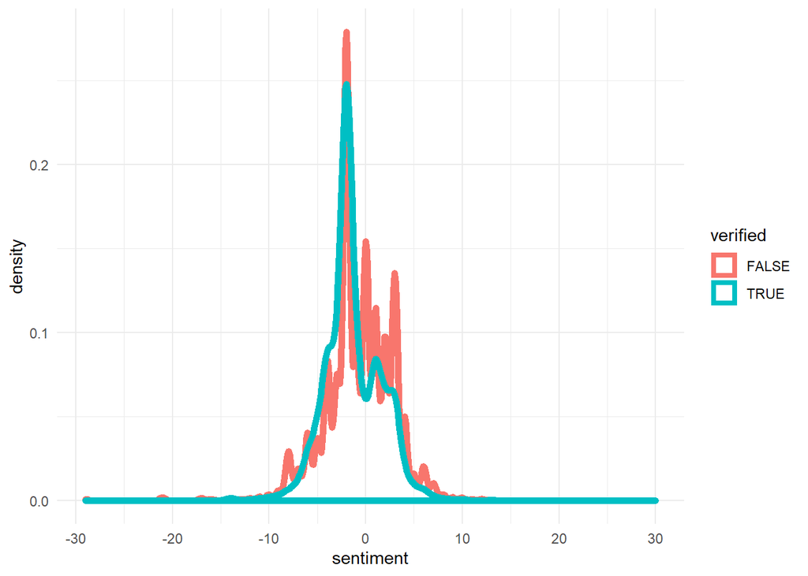

```r
ggplot(cf2, aes(x=sentiment, col=verified)) + geom_density(lwd=2) + theme_minimal()
```

See the rest of Chapter 2 in the Text mining with R book for other examples of what you can do with words and sentiments.

## Considerations

- Not all tweets (especially for COVID-19) are in English
- Records contain original, and re-tweeted content. The frequency of a word said only once, but retweeted thousands of times, may appear to be more frequent than it really is. Decide what type of tweets your group wants to analyze and apply that filter right away.
- You are likely going to be applying sentiments to the tweets at the project level, not beforehand.
  - We could, but with the variety of lexicons, and what can be done with the word level datasets, that some of this will happen at the project level anyhow.
- Don’t forget to check for abnormalities in the tweets, especially for the campfire. We can’t guarantee all tweets are about this one disaster.
- We could get into the weeds here. This is a topic of an [entire dissertation topic](https://scholarcommons.usf.edu/cgi/viewcontent.cgi?article=8925&context=etd). So don’t set your sights too high for this class project.